# Applied statistics in R

## Sampling

One of the most common operations is what is known in statistics as **sampling**: a **selection or filtering of records (rows)** (a subsample).

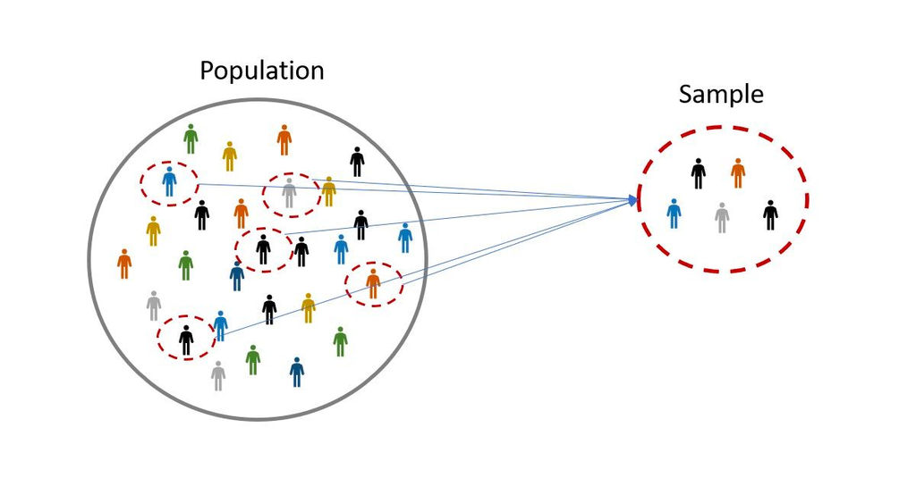

- **Non-random (by quota)**: based on logical conditions on the records (`filter()`).
- **Non-random (intentional/discretionary)**: based on a position (`slice()`).
- **Simple random** (`slice_sample()`).
- **Stratified** (`group_by()` + `slice_sample()`).

## Filter rows: filter()

```r
data |>
  filtro(condition)
```

```r
starwars |>
  filter(condition)
```

The simplest action by rows is when **filter records** based on some logical condition: with `filter()` only individuals meeting certain conditions will be selected (non-random sampling by conditions).

- `==`, `!=`: **equal** or **different** to (`|> filter(variable == "a")`)
- `>`, `<`: **greater** or **less** than (`|> filter(variable < 3)`)
- `>=`, `<=`: **greater or equal** or **less or equal** than (`|> filter(variable >= 5)`)
- `%in%`: values **belong** to a set of discrete options (`|> filter(variable %in% c("blue", "green"))`)
- `between(variable, val1, val2)`: if continuous values are **inside of a range** (`|> filter(between(variable, 160, 180))`)

## Filter rows: filter()

These **logical conditions** can be **combined** in different ways (and, or, or mutually exclusive).

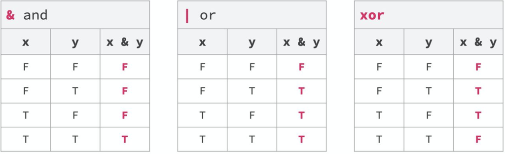

**Important**

Remember that inside `filter()` there must always be something that returns a **vector of logical values**.

## Filter rows: filter()

```r
data |>
  filtro(condition)
```

```r
starwars |>
  filter(condition)
```

How would you go about… **filter** the characters with **brown eyes**?

**What type of variable is it?** –> The `eye_color` variable is qualitative so it is represented by texts.

```r
starwars |>
  filter(eye_color == "brown")
```

```
# A tibble: 21 × 14
   name     height  mass hair_color skin_color eye_color birth_year sex   gender
   <chr>     <int> <dbl> <chr>      <chr>      <chr>          <dbl> <chr> <chr>
 1 Leia Or…    150  49   brown      light      brown           19   fema… femin…
 2 Biggs D…    183  84   black      light      brown           24   male  mascu…
 3 Han Solo    180  80   brown      fair       brown           29   male  mascu…
 4 Yoda         66  17   white      green      brown          896   male  mascu…
 5 Boba Fe…    183  78.2 black      fair       brown           31.5 male  mascu…
 6 Lando C…    177  79   black      dark       brown           31   male  mascu…
 7 Arvel C…     NA  NA   brown      fair       brown           NA   male  mascu…
 8 Wicket …     88  20   brown      brown      brown            8   male  mascu…
 9 Padmé A…    185  45   brown      light      brown           46   fema… femin…
10 Quarsh …    183  NA   black      dark       brown           62   male  mascu…
# ℹ 11 more rows
# ℹ 5 more variables: homeworld <chr>, species <chr>, films <list>,
#   vehicles <list>, starships <list>
```

## Filter rows: filter()

```r
data |>
  filtro(condition)
```

```r
starwars |>
  filter(condition)
```

How would you go about… **filter** the characters that **do not have brown eyes**?

```r
starwars |>
  filter(eye_color != "brown")
```

```
# A tibble: 66 × 14
   name     height  mass hair_color skin_color eye_color birth_year sex   gender
   <chr>     <int> <dbl> <chr>      <chr>      <chr>          <dbl> <chr> <chr>
 1 Luke Sk…    172    77 blond      fair       blue            19   male  mascu…
 2 C-3PO       167    75 <NA>       gold       yellow         112   none  mascu…
 3 R2-D2        96    32 <NA>       white, bl… red             33   none  mascu…
 4 Darth V…    202   136 none       white      yellow          41.9 male  mascu…
 5 Owen La…    178   120 brown, gr… light      blue            52   male  mascu…
 6 Beru Wh…    165    75 brown      light      blue            47   fema… femin…
 7 R5-D4        97    32 <NA>       white, red red             NA   none  mascu…
 8 Obi-Wan…    182    77 auburn, w… fair       blue-gray       57   male  mascu…
 9 Anakin …    188    84 blond      fair       blue            41.9 male  mascu…
10 Wilhuff…    180    NA auburn, g… fair       blue            64   male  mascu…
# ℹ 56 more rows
# ℹ 5 more variables: homeworld <chr>, species <chr>, films <list>,
#   vehicles <list>, starships <list>
```

## Filter rows: filter()

```r
data |>
  filtro(condition)
```

```r
starwars |>
  filter(condition)
```

How would you go about … **filter** characters that **have brown or blue eyes**?

```r
starwars |>
  filter(eye_color %in% c("blue", "brown"))
```

```
# A tibble: 40 × 14
   name     height  mass hair_color skin_color eye_color birth_year sex   gender
   <chr>     <int> <dbl> <chr>      <chr>      <chr>          <dbl> <chr> <chr>
 1 Luke Sk…    172    77 blond      fair       blue            19   male  mascu…
 2 Leia Or…    150    49 brown      light      brown           19   fema… femin…
 3 Owen La…    178   120 brown, gr… light      blue            52   male  mascu…
 4 Beru Wh…    165    75 brown      light      blue            47   fema… femin…
 5 Biggs D…    183    84 black      light      brown           24   male  mascu…
 6 Anakin …    188    84 blond      fair       blue            41.9 male  mascu…
 7 Wilhuff…    180    NA auburn, g… fair       blue            64   male  mascu…
 8 Chewbac…    228   112 brown      unknown    blue           200   male  mascu…
 9 Han Solo    180    80 brown      fair       brown           29   male  mascu…
10 Jek Ton…    180   110 brown      fair       blue            NA   <NA>  <NA>
# ℹ 30 more rows
# ℹ 5 more variables: homeworld <chr>, species <chr>, films <list>,
#   vehicles <list>, starships <list>
```

## Filter rows: filter()

```r
data |>
  filtro(condition)
```

```r
starwars |>
  filter(condition)
```

Note that `%in%` is equivalent to concatenating several `==` with a conjunction or (`|`)

```r
starwars |>
  filter(eye_color == "blue" | eye_color == "brown")
```

```
# A tibble: 40 × 14
   name     height  mass hair_color skin_color eye_color birth_year sex   gender
   <chr>     <int> <dbl> <chr>      <chr>      <chr>          <dbl> <chr> <chr>
 1 Luke Sk…    172    77 blond      fair       blue            19   male  mascu…
 2 Leia Or…    150    49 brown      light      brown           19   fema… femin…
 3 Owen La…    178   120 brown, gr… light      blue            52   male  mascu…
 4 Beru Wh…    165    75 brown      light      blue            47   fema… femin…
 5 Biggs D…    183    84 black      light      brown           24   male  mascu…
 6 Anakin …    188    84 blond      fair       blue            41.9 male  mascu…
 7 Wilhuff…    180    NA auburn, g… fair       blue            64   male  mascu…
 8 Chewbac…    228   112 brown      unknown    blue           200   male  mascu…
 9 Han Solo    180    80 brown      fair       brown           29   male  mascu…
10 Jek Ton…    180   110 brown      fair       blue            NA   <NA>  <NA>
# ℹ 30 more rows
# ℹ 5 more variables: homeworld <chr>, species <chr>, films <list>,
#   vehicles <list>, starships <list>
```

## Filter rows: filter()

```r
data |>
  filtro(condition)
```

```r
starwars |>
  filter(condition)
```

How would you go about … **filter** the characters that **are between 120 and 160 cm**?

**What type of variable is it?** –> The variable `height` is a continuous quantitative variable so we must filter by ranges of values (intervals) –> we will use `between()`.

```r
starwars |>
  filter(between(height, 120, 160))
```

```
# A tibble: 6 × 14
  name      height  mass hair_color skin_color eye_color birth_year sex   gender
  <chr>      <int> <dbl> <chr>      <chr>      <chr>          <dbl> <chr> <chr>
1 Leia Org…    150    49 brown      light      brown             19 fema… femin…
2 Mon Moth…    150    NA auburn     fair       blue              48 fema… femin…
3 Nien Nunb    160    68 none       grey       black             NA male  mascu…
4 Watto        137    NA black      blue, grey yellow            NA male  mascu…
5 Gasgano      122    NA none       white, bl… black             NA male  mascu…
6 Cordé        157    NA brown      light      brown             NA <NA>  <NA>
# ℹ 5 more variables: homeworld <chr>, species <chr>, films <list>,
#   vehicles <list>, starships <list>
```

## Filter rows: filter()

```r
data |>
  filtro(condition)
```

```r
starwars |>
  filter(condition)
```

How would you… **filter** characters that **have eyes and are not human**?

```r
starwars |>
  filter(eye_color == "brown" & species != "Human")
```

```
# A tibble: 3 × 14
  name      height  mass hair_color skin_color eye_color birth_year sex   gender
  <chr>      <int> <dbl> <chr>      <chr>      <chr>          <dbl> <chr> <chr>
1 Yoda          66    17 white      green      brown            896 male  mascu…
2 Wicket S…     88    20 brown      brown      brown              8 male  mascu…
3 Eeth Koth    171    NA black      brown      brown             NA male  mascu…
# ℹ 5 more variables: homeworld <chr>, species <chr>, films <list>,
#   vehicles <list>, starships <list>
```

## Filter rows: filter()

```r
data |>
  filtro(condition)
```

```r
starwars |>
  filter(condition)
```

How would you… **filter** characters that **have eyes and are not human, or are over 60 years old**? Think it through: the **parentheses are important**: $(a+b)*c$ is not the same as $a+(b*c)$.

```r
starwars |>
  filter((eye_color == "brown" & species != "Human") | birth_year > 60)
```

```
# A tibble: 18 × 14
   name     height  mass hair_color skin_color eye_color birth_year sex   gender
   <chr>     <int> <dbl> <chr>      <chr>      <chr>          <dbl> <chr> <chr>
 1 C-3PO       167    75 <NA>       gold       yellow           112 none  mascu…
 2 Wilhuff…    180    NA auburn, g… fair       blue              64 male  mascu…
 3 Chewbac…    228   112 brown      unknown    blue             200 male  mascu…
 4 Jabba D…    175  1358 <NA>       green-tan… orange           600 herm… mascu…
 5 Yoda         66    17 white      green      brown            896 male  mascu…
 6 Palpati…    170    75 grey       pale       yellow            82 male  mascu…
 7 Wicket …     88    20 brown      brown      brown              8 male  mascu…
 8 Qui-Gon…    193    89 brown      fair       blue              92 male  mascu…
 9 Finis V…    170    NA blond      fair       blue              91 male  mascu…
10 Quarsh …    183    NA black      dark       brown             62 male  mascu…
11 Shmi Sk…    163    NA black      fair       brown             72 fema… femin…
12 Mace Wi…    188    84 none       dark       brown             72 male  mascu…
13 Ki-Adi-…    198    82 white      pale       yellow            92 male  mascu…
14 Eeth Ko…    171    NA black      brown      brown             NA male  mascu…
15 Cliegg …    183    NA brown      fair       blue              82 male  mascu…
16 Dooku       193    80 white      fair       brown            102 male  mascu…
17 Bail Pr…    191    NA black      tan        brown             67 male  mascu…
18 Jango F…    183    79 black      tan        brown             66 male  mascu…
# ℹ 5 more variables: homeworld <chr>, species <chr>, films <list>,
#   vehicles <list>, starships <list>
```

## Drop missings: drop_na()

```r
data |>
  drop_missings(var1, var2, ...)
```

```r
starwars |>
  drop_na(var1, var2, ...)
```

There is a special **filter** for one of the most common operations in debugging: **remove absent**. For this we can use inside a filter `is.na()`, which returns `TRUE/FALSE` depending on whether it is absent, or …

Use `drop_na()`: if we do not specify a variable, it removes records with missing in any variable. Later on we will see how to **impute those missing**

```r
starwars |>
  drop_na(mass, height)
```

```
# A tibble: 7 × 4
  name                mass height hair_color
  <chr>              <dbl>  <int> <chr>
1 Luke Skywalker        77    172 blond
2 C-3PO                 75    167 <NA>
3 R2-D2                 32     96 <NA>
4 Darth Vader          136    202 none
5 Leia Organa           49    150 brown
6 Owen Lars            120    178 brown, grey
7 Beru Whitesun Lars    75    165 brown
```

```r
starwars |>
  drop_na()
```

```
# A tibble: 7 × 4
  name                mass height hair_color
  <chr>              <dbl>  <int> <chr>
1 Luke Skywalker        77    172 blond
2 Darth Vader          136    202 none
3 Leia Organa           49    150 brown
4 Owen Lars            120    178 brown, grey
5 Beru Whitesun Lars    75    165 brown
6 Biggs Darklighter     84    183 black
7 Obi-Wan Kenobi        77    182 auburn, white
```

## 💻 It’s your turn

**Try to perform the following exercises without looking at the solutions**

- **Ex 1**
- **Ex 2**
- **Ex 3**
- **Ex 4**
- **Ex 5**
- **Ex 6**
- **Ex 7**
- **Ex 8**

📝 Select from the starwars set only those characters that are androids or whose `species` value is unknown.

```r
starwars |>
  filter(species == "Droid" | is.na(species))
```

📝 Select from the starwars set only the characters whose weight is between 65 and 90 kg.

```r
starwars |> filter(between(mass, 65, 90))
```

📝 After clearing absent in all variables, select from the starwars set only the characters that are human and come from Tatooine.

```r
starwars |>
  drop_na() |>
  filter(species == "Human" & homeworld == "Tatooine")
```

📝 Select from the original starwars set non-human characters, `male` in sex and measuring between 120 and 170 cm, or characters with brown or red eyes.

```r
starwars |>
  filter((species != "Human" & sex == "male" &
            between(height, 120, 170)) |
           eye_color %in% c("brown", "red"))
```

📝 Look for information in the `str_detect()` function help of the `{stringr}` package (loaded in `{tidyverse}`). Tip: test the functions you are going to use with some test vector beforehand so that you can check how they work. After you know what it does, filter out only those characters with the last name `Skywalker`. Check the function `str_detect(string, pattern)` from the `{stringr}` package (already included in tidvyerse). Think about the differences between `str_detect()` and `contains()`

```r
starwars |> filter(str_detect(name, "Skywalker"))
```

📝 Keep only characters who have a height between 160 and 190 cm and have a mass between 50 and 90 kg and are not droids. How many characters satisfy all three conditions? Are they mostly `Human` or not?

```r
starwars_filter <-
  starwars |>
  filter(between(height, 160, 190) & between(mass, 50, 90) &
           species != "Droid")
starwars_filter |> nrow()
(starwars_filter |> filter(species == "Human") |> nrow()) >
  (starwars_filter |> filter(species != "Human") |> nrow())
```

📝 Keep only characters who belong to one of the following species (`"Human"`, `"Droid"`, `"Wookiee"`) and whose homeworld is either `"Tatooine"` or `"Naboo"`. Are there any Wookiees from Naboo ?

```r
starwars_filter <-
  starwars |>
  filter(species %in% c("Human", "Droid", "Wookiee") &
           (homeworld == "Tattoine" | homeworld == "Naboo"))
starwars_filter |>
  filter(species == "Wookie" & homeworld == "Naboo")
```

📝 Keep characters who satisfy at least one of the following:

- Height greater than 200 cm
- Mass greater than 120 kg
- Eye color is either `"red"` or `"yellow"`

BUT exclude characters whose gender is `"none"`.

```r
starwars |>
  filter((height > 200 | mass > 120 | eye_color %in% c("red", "yellow")) &
           gender != "none")
```

## Select columns: select()

```r
data |> select(var1, var2, ...)
```

```r
starwars |> select(var1, var2, ...)
```

Up to now all operations performed (even if we used column info) were by rows. In the case of columns, the simplest action is to **select variables by name** with `select()`, giving as arguments the column names **without quotes**.

```r
starwars |> select(name, hair_color)
```

```
# A tibble: 87 × 2
   name               hair_color
   <chr>              <chr>
 1 Luke Skywalker     blond
 2 C-3PO              <NA>
 3 R2-D2              <NA>
 4 Darth Vader        none
 5 Leia Organa        brown
 6 Owen Lars          brown, grey
 7 Beru Whitesun Lars brown
 8 R5-D4              <NA>
 9 Biggs Darklighter  black
10 Obi-Wan Kenobi     auburn, white
# ℹ 77 more rows
```

## Select columns: select()

```r
data |> select(var1, var2, ...)
```

```r
starwars |> select(var1, var2, ...)
```

The `select()` function allows us to select several variables at once, including **concatenating their names as if they were numerical indexes** with `:`

```r
starwars |> select(name:eye_color)
```

```
# A tibble: 4 × 6
  name           height  mass hair_color skin_color  eye_color
  <chr>           <int> <dbl> <chr>      <chr>       <chr>
1 Luke Skywalker    172    77 blond      fair        blue
2 C-3PO             167    75 <NA>       gold        yellow
3 R2-D2              96    32 <NA>       white, blue red
4 Darth Vader       202   136 none       white       yellow
```

And we can **unselect columns** with `-` in front of it (reminder: `-` for names/indexes and `!` for logical values)

```r
starwars |>  select(-mass, -(eye_color:starships))
```

```
# A tibble: 4 × 4
  name           height hair_color skin_color
  <chr>           <int> <chr>      <chr>
1 Luke Skywalker    172 blond      fair
2 C-3PO             167 <NA>       gold
3 R2-D2              96 <NA>       white, blue
4 Darth Vader       202 none       white
```

## Select columns: select()

```r
data |> select(var1, var2, ...)
```

```r
starwars |> select(var1, var2, ...)
```

We have also **reserved words**: `everything()` **all variables**….

```r
starwars |> select(mass, homeworld, everything())
```

```
# A tibble: 4 × 14
   mass homeworld name   height hair_color skin_color eye_color birth_year sex
  <dbl> <chr>     <chr>   <int> <chr>      <chr>      <chr>          <dbl> <chr>
1    77 Tatooine  Luke …    172 blond      fair       blue            19   male
2    75 Tatooine  C-3PO     167 <NA>       gold       yellow         112   none
3    32 Naboo     R2-D2      96 <NA>       white, bl… red             33   none
4   136 Tatooine  Darth…    202 none       white      yellow          41.9 male
# ℹ 5 more variables: gender <chr>, species <chr>, films <list>,
#   vehicles <list>, starships <list>
```

…and `last_col()` to refer to **last column**.

```r
starwars |> select(name:mass, homeworld, last_col())
```

```
# A tibble: 4 × 5
  name           height  mass homeworld starships
  <chr>           <int> <dbl> <chr>     <list>
1 Luke Skywalker    172    77 Tatooine  <chr [2]>
2 C-3PO             167    75 Tatooine  <chr [0]>
3 R2-D2              96    32 Naboo     <chr [0]>
4 Darth Vader       202   136 Tatooine  <chr [1]>
```